# Exam - Machine Learning 1

Peer Woyczechowski

12/11/2020

# Question 1

## Load Data

```r
options(scipen = 999, digits = 8)
audit <- read.csv("/Users/peerwoyzcechowski/Desktop/Uni/BI/1. semester/Maschine Learning 1/7 Applied Data Work/audit2.csv")

audit[, c(3, 6, 7, 9:11)] <- lapply(audit[, c(3, 6, 7, 9:11)], as.factor)  #specify categorical variables
```

## Standardize predictors

```r
audit <- audit %>% mutate_at(c("Sector_score", "PARA_A", "PARA_B", "TOTAL", "Money_Value"),
    ~(scale(., center = T, scale = T) %>% as.vector))

# checking mean=0 and sd=1
x <- c("Sector_score", "PARA_A", "PARA_B", "TOTAL", "Money_Value")
sapply(audit[x], sd)
```

```
## Sector_score       PARA_A       PARA_B        TOTAL  Money_Value
##            1            1            1            1            1
```

```r
sapply(audit[x], mean)
```

```
##                Sector_score                      PARA_A
##  0.000000000000000097389195  0.000000000000000026474591
##                      PARA_B                       TOTAL
##  0.000000000000000010222907 -0.000000000000000017663909
##                 Money_Value
## -0.000000000000000016274312
```

## Split data in test and train

```r
# dim(audit) train <- audit$Risk audit_train <- audit[1:1162,] audit_test <-
# audit[1162:1550,] dim(audit_train) dim(audit_test)

set.seed(123, "L'Ecuyer")
(1162/1550)
```

```
## [1] 0.74967742
```

```r
Training <- createDataPartition(audit$Risk, p = 0.75, list = FALSE)
audit_train <- audit[Training, ]
audit_test <- audit[-Training, ]
dim(audit_train)
```

```
## [1] 1163   12
```

```r
# some factors have different levels in the training and validation data set,
# hence I'm deleting those
uniquetrain1 <- unique(audit_train$History)
test <- audit_test[audit_test$History %in% uniquetrain1, ]
```

Somehow, when I partition my data by the first 1162 records later models are not working, thus, I used stratified data partinioning with 75% in the training set which is not exactly the same proportions. I end up with one more observation in the training set than specified in the exercise. I will continue with the stratified partitoned dataset.

## Share of Risk assigned observations in each data set

```
##
##          0          1
## 0.56749785 0.43250215
```

```
##
##          0          1
## 0.53488372 0.46511628
```

The distribution of Risk in the training set is .57 for Risk=0 and .43 for Risk=1. The distribution of Risk in the test set is .53 for Risk=0 and .47 for Risk=1.

# Question 2

## Logistic regression

```r
## logistic regression
glm2 <- glm(Risk ~. , data = audit_train, family = "binomial")


## Predictions on train data
glm_probs <- predict(glm2, newdata = audit_train , type = "response")

## Predictions on test data
glm_probs2 <- predict(glm2, newdata = audit_test , type = "response")


## Confusion Matrix (train)
confusionMatrix(factor(ifelse(glm_probs>0.5,"1","0")), #using 0.5 as cutoff level
                factor(audit_train$Risk), positive = "1") #defines the important category -- Risk=1
```

```
## Confusion Matrix and Statistics
##
##           Reference
## Prediction   0   1
##          0 553 185
##          1 107 318
##
##                Accuracy : 0.74893
##                  95% CI : (0.72296, 0.77362)
##     No Information Rate : 0.5675
##     P-Value [Acc > NIR] : < 0.000000000000000222
##
##                   Kappa : 0.47892
##
##  Mcnemar's Test P-Value : 0.0000066035
##
##             Sensitivity : 0.63221
##             Specificity : 0.83788
##          Pos Pred Value : 0.74824
##          Neg Pred Value : 0.74932
##              Prevalence : 0.43250
##          Detection Rate : 0.27343
##    Detection Prevalence : 0.36543
##       Balanced Accuracy : 0.73504
##
##        'Positive' Class : 1
##
```

```r
## Confusion Matrix (test)
confusionMatrix(factor(ifelse(glm_probs2>0.5,"1","0")), #using 0.5 as cutoff level
                factor(audit_test$Risk), positive = "1") #defines the important category -- Risk=1
```

```
## Confusion Matrix and Statistics
##
##           Reference
## Prediction   0   1
##          0 179  73
##          1  28 107
##
##                Accuracy : 0.73902
##                  95% CI : (0.69225, 0.78209)
##     No Information Rate : 0.53488
##     P-Value [Acc > NIR] : < 0.000000000000000222
##
##                   Kappa : 0.46679
##
##  Mcnemar's Test P-Value : 0.000011968
##
##             Sensitivity : 0.59444
##             Specificity : 0.86473
##          Pos Pred Value : 0.79259
##          Neg Pred Value : 0.71032
##              Prevalence : 0.46512
##          Detection Rate : 0.27649
##    Detection Prevalence : 0.34884
##       Balanced Accuracy : 0.72959
##
##        'Positive' Class : 1
##
```

Interpretation: We obtain a .75 accuracy for the prediction on the training data and a .74 accuracy for the predicition on the test data. It is expected that the accuracy on the training data prediction is higher since the model was trained on that data. However, one can observe that there is no big difference between the two accuracy values, indicating that we did not overfit the data during training.

# Question 3

```r
## logistic regression (interactions) using train data
glm3 <- glm(Risk ~ .:., data = audit_train, family = "binomial")  #added twoway interact.
summaryglm3 <- summary(glm3)

# In-sample error
ext.insample <- summaryglm3$deviance
# the deviance in the logistic regression is equivalent to the in-sample error
# (log likelihood function)

# AIC
ext.aic <- summaryglm3$aic

# BIC
ext.bic <- BIC(glm3)

## Logistic regression (no interactions)
summaryglm2 <- summary(glm2)
# In-sample error
insample <- summaryglm2$deviance

# AIC
aic <- summaryglm2$aic

# BIC
bic <- BIC(glm2)

## Compare
cbind(insample, ext.insample)
```

```
##       insample ext.insample
## [1,] 1237.9152    22058.716
```

```r
cbind(aic, ext.aic)
```

```
##            aic   ext.aic
## [1,] 1285.9152 22380.716
```

```r
cbind(bic, ext.bic)
```

```
##            bic   ext.bic
## [1,] 1407.3254 23195.176
```

Interpretaion:

The first logistic regression outperforms the second model that includes interactions between all predictors in terms of all criteria: in-sample error, AIC, and BIC. This is expected since by introducing the interaction terms, the problem at hand becomes more complex (i.e. higer dimensionality). A logistic regression’s variance increases with increasing dimensionality. The model has high variance and low bias and thus overfits the data which results in a high in-sample error and much higher AIC and BIC values. Overall, the logistic regression in a high-dimensional problem often has low bias but high variance and since the expected in-sample error is a combination of these two quantities, we see higher values for the model with interactions.

# Question 4

I will use the Bayesian Model Averaging technique in the following question since the question asks if the chosen model is the true model

```r
## BMA
audit_train$Risk <- as.factor(audit_train$Risk)

dim(audit_train)
```

```
## [1] 1163   12
```

```r
maBIC <- mami(audit_train, outcome = "Risk", model = "binomial", method = "MA.criterion",
    criterion = "BIC")
```

```
## Note: The following variables are treated as factors: Risk Score_A numbers Score_B.1 Score_MV District_Loss History
## Busy with model averaging in imputed dataset no. 1
## Model averaging was based on 2048 candidate models
```

```r
maBIC$variable.importance
```

```
##      factor(Score_MV) factor(District_Loss)       factor(Score_A)
##     0.999999999566030     0.999999984781973     0.999999882006637
##                 TOTAL                PARA_B                PARA_A
##     0.999872983533705     0.809360497337793     0.756280528092048
##          Sector_score           Money_Value     factor(Score_B.1)
##     0.421628254126959     0.182571366234827     0.010643437663536
##       factor(numbers)       factor(History)
##     0.000024062860475     0.000000069881868
```

```r
maBIC$coefficients.ma
```

```
##                                  Estimate     Std.Error       Lower CI
## (Intercept)            -1.062962617846269 0.11256715789 -1.28359019316
## factor(District_Loss)4  0.565418024069150 0.27135966703  0.03356284984
## factor(District_Loss)6  1.581439890113741 0.23849651306  1.11399531407
## factor(History)1        0.000000041195665 0.00018829598 -0.00036901214
## factor(History)2       -0.000000011340105 0.00019266043 -0.00037761885
## factor(History)3       -0.000000115526756 0.00069699206 -0.00136619486
## factor(History)4        0.000000092129909 0.00051234368 -0.00100408302
## factor(History)5        0.000000987808529 0.13564158675 -0.26585163703
## factor(History)9        0.000001112490628 0.23339273706 -0.45744024640
## factor(numbers)5.5      0.000017184084465 0.00383712911 -0.00750345078
## factor(numbers)6        0.000018246864344 0.00484750799 -0.00948269421
## factor(numbers)6.5     -0.000006801995333 0.00411137746 -0.00806495374
## factor(numbers)9        0.000278816987680 2.01564947364 -3.95032155680
## factor(Score_A)0.4      0.211710475921895 0.18148086616 -0.14398548564
## factor(Score_A)0.6      1.148347728092372 0.17261524710  0.81002806059
## factor(Score_B.1)0.4    0.004454069283325 0.05407389754 -0.10152882239
## factor(Score_B.1)0.6    0.009535360547676 0.10498433378 -0.19623015260
## factor(Score_MV)0.4     0.860147956399825 0.28251519678  0.30642834562
## factor(Score_MV)0.6     1.374237663130636 0.19209874732  0.99773103691
## Money_Value             0.031623526344404 0.07774603989 -0.12075591179
## PARA_A                  0.211568505038206 0.15068381907 -0.08376635339
## PARA_B                  0.474626674556657 0.28709671121 -0.08807253950
## Sector_score           -0.075712372947264 0.10000771427 -0.27172389109
## TOTAL                   0.852224856663069 0.19309269198  0.47377013471
##                              Upper CI
## (Intercept)            -0.84233504253
## factor(District_Loss)4  1.09727319830
## factor(District_Loss)6  2.04888446616
## factor(History)1        0.00036909453
## factor(History)2        0.00037759617
## factor(History)3        0.00136596381
## factor(History)4        0.00100426728
## factor(History)5        0.26585361265
## factor(History)9        0.45744247138
## factor(numbers)5.5      0.00753781894
## factor(numbers)6        0.00951918794
## factor(numbers)6.5      0.00805134975
## factor(numbers)9        3.95087919077
## factor(Score_A)0.4      0.56740643748
## factor(Score_A)0.6      1.48666739560
## factor(Score_B.1)0.4    0.11043696096
## factor(Score_B.1)0.6    0.21530087370
## factor(Score_MV)0.4     1.41386756718
## factor(Score_MV)0.6     1.75074428935
## Money_Value             0.18400296448
## PARA_A                  0.50690336347
## PARA_B                  1.03732588861
## Sector_score            0.12029914519
## TOTAL                   1.23067957861
```

BMA is used to find the true model within a subset of models. If there is a true model, the BMA will pick the right model in the long-run (as sample size gets bigger and bigger or in theory if you would have an infinite sample). However, since we do not have an infinite sample at hand, we are only approximating the true model. Hence, for finite samples, the BMA will always combine different models and use some information from other models to stabilize the estimate i.e. smoothing the BICs for each model and approximating the true model. To sum up, the chosen model is probabily not the true model but just an approximation.

The mami package gives variable importance measure that is averaged over the M imputed data sets. The measure sums up the weights w_k of those candidate models M_k that contain the relevant variable, and lies between 0 (unimportant) and 1 (very important). Looking at the variable importance, we observe that the BMA model includes all variables, however, one can clearly see that Score_MV, District_Loss, Score_A, TOTAL, PARA_B and PARA_A are the most important variables compared to the rest of the variables. Hence, the BMA model gives the majority of weight to models that include the mentioned variables and less to the remaining variables. Especially, numbers and History seem to be less relevant in terms of finding the true model among a subset of models.

# Question 5

## extending data

I will use a blueprint to create the squared predictors and two-way interactions. To create interactions between all the factor variables, I will create dummies before doing the interactions.

```r
## 1. define recipe
blueprint <- recipe(Risk ~ ., data = audit_train) %>%
  step_poly(Sector_score,PARA_A,PARA_B,TOTAL,Money_Value
              ,degree = 2 #We want second order polynomial
              ,options = list(raw = TRUE)
              )%>%
  step_dummy(all_nominal(), -Risk, one_hot = T)%>% #needs to create dummies to do interactions between all predictors
  step_interact(terms = ~ all_predictors():all_predictors())%>%
  step_zv(all_predictors()) #trims the dummy variables that are interacted with each other


## 2. prepare recipe
prepare <- prep(blueprint, training = audit_train)
prepare
```

```
## Data Recipe
##
## Inputs:
##
##       role #variables
##    outcome          1
##  predictor         11
##
## Training data contained 1163 data points and no missing data.
##
## Operations:
##
## Orthogonal polynomials on Sector_score, PARA_A, PARA_B, ... [trained]
## Dummy variables from Score_A, numbers, Score_B.1, Score_MV, ... [trained]
## Interactions with (Sector_score_poly_1 + Sector_score_poly_2 + PARA_A_poly_1 + PARA_A_poly_2 + PARA_B_poly_1 + PARA_B_poly_2 + TOTAL_poly_1 + TOTAL_poly_2 + Money_Value_poly_1 + Money_Value_poly_2 + Score_A_X0.2 + Score_A_X0.4 + Score_A_X0.6 + numbers_X5 + numbers_X5.5 + numbers_X6 + numbers_X6.5…
##     History_X4 + History_X5 + History_X9):(Sector_score_poly_1 + Sector_score_poly_2 + PARA_A_poly_1 + PARA_A_poly_2 + PARA_B_poly_1 + PARA_B_poly_2 + TOTAL_poly_1 + TOTAL_poly_2 + Money_Value_poly_1 + Money_Value_poly_2 + Score_A_X0.2 + Score_A_X0.4 + Score_A_X0.6 + numbers_X5 + numbers_X5.5 + n…
##     History_X1 + History_X2 + History_X3 + History_X4 + History_X5 + History_X9) [trained]
## Zero variance filter removed 96 items [trained]
```

```r
## 4. bake train data
bake.train <- bake(prepare, new_data = audit_train)
bake.test <- bake(prepare, new_data = audit_test)
dim(bake.train)
```

```
## [1] 1163  500
```

```r
dim(bake.test)
```

```
## [1] 387 500
```

```r
# Now, the dataset has 500 variables.
```

# L1 Regularization

I chose to do L1 Regularization. I will select the optimal tuning parameter via 10-fold cross-validation.

```r
## PREPARE
glm.test <- glm(Risk ~ ., data = bake.test, family = "binomial")
glm.train <- glm(Risk ~ ., data = bake.train, family = "binomial")
x <- model.matrix(glm.train)[, !is.na(glm.train$coefficients)][, -1]
x_test <- model.matrix(glm.test)[, !is.na(glm.train$coefficients)][, -1]
y <- bake.train$Risk
y_test <- as.numeric(bake.test$Risk)
l.grid <- 10^seq(3, -2, length = 100)  # setting up a grid of lambda


## L1 cv.glmnet using cv to determine the optimal lambda
l1 <- cv.glmnet(x, y, alpha = 1, lambda = l.grid, nfolds = 10, family = "binomial",
    type.measure = "class")
l1.lam <- l1$lambda.min
l1.lam
```

```
## [1] 0.017886495
```

```r
## TEST prediction (test)
l1.pred <- predict(l1, s = l1.lam, newx = x_test)

# performance (test)
l1.predicted.classes <- ifelse(l1.pred > 0.5, "1", "0")
l1.observed.classes <- bake.test$Risk
acc.test <- mean(l1.predicted.classes == l1.observed.classes)

## TRAIN prediction (train)
l1.pred.train <- predict(l1, s = l1.lam, newx = x)  #x=train data

# performance (train)
l1.predicted.classes.train <- ifelse(l1.pred.train > 0.5, "1", "0")
l1.observed.classes.train <- bake.train$Risk
acc.train <- mean(l1.predicted.classes.train == l1.observed.classes.train)

## Compare
cbind(acc.test, acc.train)
```

```
##        acc.test  acc.train
## [1,] 0.71317829 0.70507309
```

# Question 6

```r
## NOTE: scale and center predictors and make dummies
listWrappers()
## 1. Choose models logistic regression Elastic Net


## 2. Preparation
x_train.sl <- bake.train[, -1]  #exclude Risk
y_train.sl <- as.numeric(unlist(bake.train[, 1]))

## 3. Modeling
SL <- SuperLearner(Y = y_train.sl, X = x_train.sl, method = "method.NNloglik", family = binomial,
    SL.library = c("SL.glm", "SL.nnet"))
SL

# IF MY SUPERLEARNER WOULD BE FASTER, I WOULD HAVE PREDICTED AS BELOW 4.
# Prediction get model averaging weights and predicitions (In-Sample)
SL$coef
SL$SL.predict

sl.pred <- predict(SL, newdata = bake.test[, -1])  #exclude Risk
as.numeric(sl.pred)
sl.pred$pred

## 5. Peformance
sl.predicted.classes <- ifelse(sl.pred$pred > 0.5, "1", "0")
sl.observed.classes <- bake.test$Risk
sl.acc <- mean(sl.predicted.classes == sl.observed.classes)
sl.acc
```

# **************Problem 2************

# Question 1

## Load Data

```r
options(scipen = 999, digits = 8)
audit.p2 <- read.csv("/Users/peerwoyzcechowski/Desktop/Uni/BI/1. semester/Maschine Learning 1/7 Applied Data Work/audit2.csv")

audit.p2[, c(3, 6, 7, 9:12)] <- lapply(audit.p2[, c(3, 6, 7, 9:12)], as.factor)  #specify categorical variables
```

## Disretize

```r
## binning of numeric variables
audit.p2$Sector_score <- ifelse(audit.p2$Sector_score >= (median(audit.p2$Sector_score)),
    "High", "Low")
audit.p2$PARA_A <- ifelse(audit.p2$PARA_A >= (median(audit.p2$PARA_A)), "High", "Low")
audit.p2$PARA_B <- ifelse(audit.p2$PARA_B >= (median(audit.p2$PARA_B)), "High", "Low")
audit.p2$TOTAL <- ifelse(audit.p2$TOTAL >= (median(audit.p2$TOTAL)), "High", "Low")
audit.p2$Money_Value <- ifelse(audit.p2$Money_Value >= (median(audit.p2$Money_Value)),
    "High", "Low")

# CHECK
head(audit.p2)
```

```
##   Sector_score PARA_A Score_A PARA_B TOTAL numbers Score_B.1 Money_Value
## 1         High   High     0.6   High  High       5       0.2        High
## 2          Low   High     0.6   High   Low       5       0.2        High
## 3         High    Low     0.2    Low  High       5       0.2         Low
## 4         High    Low     0.2    Low   Low       5       0.2         Low
## 5         High    Low     0.2    Low   Low       5       0.6         Low
## 6         High    Low     0.2    Low   Low       5       0.2         Low
##   Score_MV District_Loss History Risk
## 1      0.4             2       0    1
## 2      0.2             2       0    1
## 3      0.2             2       0    0
## 4      0.2             6       0    1
## 5      0.2             2       0    1
## 6      0.2             2       0    0
```

# Question 2

## data partioning

```r
dim(audit.p2)
```

```
## [1] 1550   12
```

```r
(1162/1550)
```

```
## [1] 0.74967742
```

```r
set.seed(123, "L'Ecuyer")
Training <- createDataPartition(audit.p2$Risk, p = 0.75, list = FALSE)
p2.audit_train <- audit.p2[Training, ]
p2.audit_test <- audit.p2[-Training, ]

dim(p2.audit_test)
```

```
## [1] 386  12
```

```r
dim(p2.audit_train)
```

```
## [1] 1164   12
```

## Naive bayes classifier

```r
audit.nb <- naiveBayes(Risk ~., data = p2.audit_train)

#a-prior
audit.nb$apriori
```

```
## Y
##   0   1
## 651 513
```

```r
#conditional probabilities
audit.nb$tables
```

```
## $Sector_score
##    Sector_score
## Y         High        Low
##   0 0.56374808 0.43625192
##   1 0.43859649 0.56140351
##
## $PARA_A
##    PARA_A
## Y         High        Low
##   0 0.39016897 0.60983103
##   1 0.65302144 0.34697856
##
## $Score_A
##    Score_A
## Y          0.2        0.4        0.6
##   0 0.63287250 0.19508449 0.17204301
##   1 0.36647173 0.17738791 0.45614035
##
## $PARA_B
##    PARA_B
## Y         High        Low
##   0 0.39324117 0.60675883
##   1 0.64327485 0.35672515
##
## $TOTAL
##    TOTAL
## Y         High        Low
##   0 0.38863287 0.61136713
##   1 0.64132554 0.35867446
##
## $numbers
##    numbers
## Y              5          5.5            6          6.5            9
##   0 0.9493087558 0.0353302611 0.0076804916 0.0076804916 0.0000000000
##   1 0.8576998051 0.0974658869 0.0311890838 0.0097465887 0.0038986355
##
## $Score_B.1
##    Score_B.1
## Y           0.2         0.4         0.6
##   0 0.955453149 0.033794163 0.010752688
```

[output cut: 14 more lines]

```
## $District_Loss
##    District_Loss
## Y             2           4           6
##   0 0.909370200 0.049155146 0.041474654
##   1 0.760233918 0.076023392 0.163742690
##
## $History
##    History
## Y              0            1            2            3            4
##   0 0.9677419355 0.0230414747 0.0046082949 0.0030721966 0.0015360983
##   1 0.8947368421 0.0740740741 0.0194931774 0.0038986355 0.0019493177
##    History
## Y              5            9
##   0 0.0000000000 0.0000000000
##   1 0.0019493177 0.0038986355
```

```r
#Performance eval
pred.prob <- predict(audit.nb, newdata = p2.audit_test, type = "raw") #raw to get


confusionMatrix(factor(ifelse(pred.prob[,2]>0.5,"1","0")), #using 0.5 as cutoff level
                factor(p2.audit_test$Risk), positive = "1")
```

```
## Confusion Matrix and Statistics
##
##           Reference
## Prediction   0   1
##          0 167  62
##          1  49 108
##
##                Accuracy : 0.71244
##                  95% CI : (0.66447, 0.7571)
##     No Information Rate : 0.55959
##     P-Value [Acc > NIR] : 0.00000000046117
##
##                   Kappa : 0.4118
##
##  Mcnemar's Test P-Value : 0.25471
##
##             Sensitivity : 0.63529
##             Specificity : 0.77315
##          Pos Pred Value : 0.68790
##          Neg Pred Value : 0.72926
##              Prevalence : 0.44041
##          Detection Rate : 0.27979
##    Detection Prevalence : 0.40674
##       Balanced Accuracy : 0.70422
##
##        'Positive' Class : 1
##
```

```r
Type1 <- 1-(0.77315) #specificity
Type2 <- 1-(0.63529 ) #sensitivity
Type1
```

```
## [1] 0.22685
```

```r
Type2
```

```
## [1] 0.36471
```

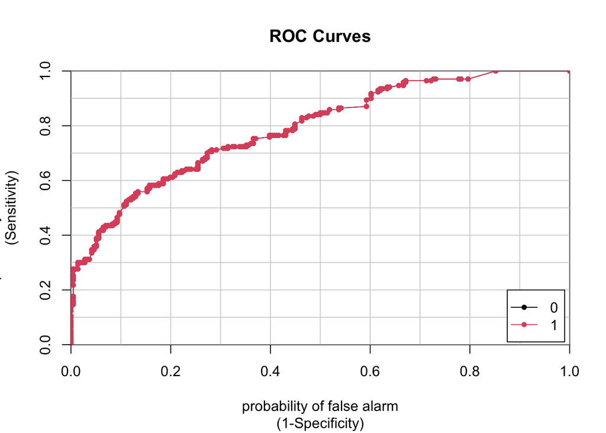

```
##                  0          1
## 0 vs. 1 0.78944717 0.78944717
```

```r
#AUC
colAUC(pred.prob, p2.audit_test$Risk, plotROC = T)
```

– a-priori – The apriori output gives the class distribution for the dependent variable. The training set contains 651 Risk=0 observations and 513 Risk=1 observations.

–conditional probabilities – The output gives a table for each attribute level which contain the conditional probabilities given the target class. For example, for Money_value the conditional probability estimated for a firm being labeled “high” on money_value in the class Risk=1 is 0.66 while the probability for a firm being labeled as “High” on money value in the class Risk=0 is just 0.38. The conditional probailites are given for each predictor value for the two classes Risk=0 and Risk=1.

–Evaluate the performance – The naive bayes model predicts with an accuracy of .71. The specificity of the model is .77 and specificity is .64. The area under the curve amounts to .79.

In terms of Type-1 error (false-positive) we can calculate the 1-specificity which is 0.22685. The type-2 error are false-negatives, hence, we can calculate it by 1-sensitivity which is 0.36471.

# Question 3

The advantages of Naive Bayes over other more complex models are mainly its simplicity and computational efficiency. For example, it is much more efficient than predictions through regularization techniques that obtain optimal tuning parameters via cross-validation.

Furthermore, NAive Bayes has the ability to handle categorical variables directly which is not possible for most other techniques. One would almost always have to create dummy variables before using a model or the model treats the categorical variables as dummies. Hence, Naive Bayes can handle both categorical and numerical data.

Naive Bayes relies on the assumption of independence between predictor variables within each class, when this assumption is not violated, naive bayes often outperforms more sophisticated techniques. For example, if the independence assumption holds it will converge quicker than discriminative models like logistic regression. However, in this case, we cannot compare the tw models directly since we discretized variables in problem 2. Nevertheless, even when the underlying assumption of independent predictors is far from true (especially when there is a large amount of predictors), naive bayes sometimes still outperforms other classifiers.

Naive Bayes is also less sensitive to irrelevant features.

# Question 4

Estimate the probability of fraud for a firm with a high risk score value of the target-unit from summary report A and a high risk score value of the target-unit from summary report B.1. Using the Naive Bayes model with all the predictors (point 2.).

```r
## P(Risk = 1 | Score_A= 0.6, Score_B1= 0.6).
tables <- audit.nb$tables

# P(Risk = 1)
priorRisk1 <- prop.table(audit.nb$apriori)
risk1 <- priorRisk1[2]

# P(PARA_A= High|Risk = 1)
scoreA1_risk1 <- tables$Score_A[2, 3]


# P(PARA_B= High|Risk = 1)
scoreB1_risk1 <- tables$Score_B.1[2, 3]


# P(PARA_A= High|Risk = 0)
scoreA1_risk0 <- tables$Score_A[1, 3]


# P(PARA_B= High|Risk = 0)
scoreB1_risk0 <- tables$Score_B.1[1, 3]

# P(Risk = 0)
risk0 <- priorRisk1[1]


## P(Risk = 1 | PARA_A = High, PARA_B= High).

# naive bayes formula P(Risk = 1 | PARA_A = High, PARA_B= High) = P(Risk = 1) *
# P(PARA_A= High|Risk = 1) * P(PARA_B= High|Risk = 1) / P(Risk = 1) * [P(PARA_A=
# High|Risk = 1) * P(PARA_B = High | Risk = 1)] + P(Risk = 0) *[P(PARA_A= High |
# Risk = 0) * P(PARA_B= High | Risk = 0)]

nb.probability <- (risk1 * (scoreA1_risk1 * scoreB1_risk1)/((risk1 * (scoreA1_risk1 *
    scoreB1_risk1)) + (risk0 * (scoreA1_risk0 * scoreB1_risk0))))
nb.probability
```

```
##          1
## 0.90447976
```

The probability of fraud for a firm with a high risk score (0.6) from summary report A and a high risk score value of the target-unit from summary report B.1 (0.6) is 90% and thus extremely high.

## Evaluate which combination of predictors and their corresponding values is associated with the highest probability of fraud.

I will use an empirical approach to determine the combination of predictors that are assoicated with the highest probability of fraud

```r
# p2.audit_train
pred.train <- predict(audit.nb, newdata = p2.audit_train, type = "raw")  #raw to get

probabilities <- pred.train[, 2]
p2.audit_train$prob <- probabilities  #store probabilites in dataset


audit_prob <- p2.audit_train[order(-p2.audit_train$prob), ]  # minus indicate descending, hence highest prob first
head(audit_prob, 10)  #get 5 highest probabilites for Risk=1
```

```
##      Sector_score PARA_A Score_A PARA_B TOTAL numbers Score_B.1 Money_Value
## 1153          Low   High     0.6   High  High     5.5       0.4        High
## 817           Low   High     0.6   High  High       6       0.6        High
## 1128          Low   High     0.6   High  High       6       0.6        High
## 1233         High   High     0.6   High  High       6       0.6        High
## 1097          Low   High     0.6   High  High     5.5       0.4        High
## 507           Low   High     0.6   High  High       6       0.6        High
## 1183          Low   High     0.6   High  High       6       0.6        High
## 960           Low   High     0.6   High  High     5.5       0.4        High
## 1236          Low   High     0.6   High  High     5.5       0.4        High
## 786          High   High     0.4   High  High     5.5       0.4        High
##      Score_MV District_Loss History Risk       prob
## 1153      0.6             6       2    1 0.99992051
## 817       0.6             6       0    1 0.99983336
## 1128      0.6             2       2    1 0.99982799
## 1233      0.6             6       0    1 0.99972439
## 1097      0.6             6       0    1 0.99963642
## 507       0.6             4       0    1 0.99957472
## 1183      0.6             4       0    1 0.99957472
## 960       0.6             2       1    1 0.99950627
## 1236      0.6             2       1    1 0.99950627
## 786       0.6             6       1    1 0.99949577
```

The highest probability of fraud are associated with: sector_score = Low PARA_A = High Score_A = 0.6 PARA_B = High TOTAL = High numbers = 5.5 and 6 (higher end) Score_B1 = 0.6 and 0.4 Money_Values = HIgh Score_MV = 0.6 District_Loss = 6 (4/5) History = 0 or 2 (low) Hence, one can conlclude that higher discrepancies found in the reports found, increase the proabbility of being fraudulent. Also having any higher risk score increases the probability of being fradulent. In contrast, it seems like that the historical loss suffered may not be that relevant since there are 3/5 0 loss suffered firms with extrmely high proability. Also, a lower sector_score i.e. historical risk score value of the target unit may increase the probaility of being fradulent.